# Homework 1- Data 621

Meaghan Burke

September 17, 2018

## 1. DATA EXPLORATION (25 Points)

Describe the size and the variables in the moneyball training data set. Consider that too much detail will cause a manager to lose interest while too little detail will make the manager consider that you aren’t doing your job. Some suggestions are given below. Please do NOT treat this as a check list of things to do to complete the assignment. You should have your own thoughts on what to tell the boss. These are just ideas.

1. Mean / Standard Deviation / Median
2. Bar Chart or Box Plot of the data
3. Is the data correlated to the target variable (or to other variables?)
4. Are any of the variables missing and need to be imputed “fixed”?

### Train Data Exploration

- Read in the data set
- Calculate the summary statistics
- 1st Qu., 3rd Qu., Max., Mean, Median, Min., NA.COUNT, Unique.Values, Standard.Dev
- Correlation
- Visualizations (density plot, scatter plot, correlation)

#### Initial Sample Train.Data/Dimensions of Train.Data

| Train.Data Dimensions |
| --- |
| 2276 |
| 16 |

| TARGET_WINS | BATTING_H | BATTING_2B | BATTING_3B | BATTING_HR | BATTING_BB | BATTING_SO | BASERUN_SB | BASERUN_CS | BATTING_HBP | PITCHING_H | PITCHING_HR | PITCHING_BB | PITCHING_SO | FIELDING_E | FIELDING_DP |
| --- | --- | --- | --- | --- | --- | --- | --- | --- | --- | --- | --- | --- | --- | --- | --- |
| 39 | 1445 | 194 | 39 | 13 | 143 | 842 | NA | NA | NA | 9364 | 84 | 927 | 5456 | 1011 | NA |
| 70 | 1339 | 219 | 22 | 190 | 685 | 1075 | 37 | 28 | NA | 1347 | 191 | 689 | 1082 | 193 | 155 |
| 86 | 1377 | 232 | 35 | 137 | 602 | 917 | 46 | 27 | NA | 1377 | 137 | 602 | 917 | 175 | 153 |
| 70 | 1387 | 209 | 38 | 96 | 451 | 922 | 43 | 30 | NA | 1396 | 97 | 454 | 928 | 164 | 156 |
| 82 | 1297 | 186 | 27 | 102 | 472 | 920 | 49 | 39 | NA | 1297 | 102 | 472 | 920 | 138 | 168 |
| 75 | 1279 | 200 | 36 | 92 | 443 | 973 | 107 | 59 | NA | 1279 | 92 | 443 | 973 | 123 | 149 |

#### Summary Statistics Dataframe

| Variable.Name | 1st Qu. | 3rd Qu. | Max. | Mean | Median | Min. | NA.COUNT | Unique.Values | Standard.Dev |
| --- | --- | --- | --- | --- | --- | --- | --- | --- | --- |
| BASERUN_CS | 38 | 62 | 201 | 52 | 49 | 0 | 772 | 129 | 22.95634 |
| BASERUN_SB | 66 | 156 | 697 | 124 | 101 | 0 | 131 | 349 | 87.79117 |
| BATTING_2B | 208 | 273 | 458 | 241 | 238 | 69 | 0 | 240 | 46.80141 |
| BATTING_3B | 34 | 72 | 223 | 55 | 47 | 0 | 0 | 144 | 27.93856 |
| BATTING_BB | 451 | 580 | 878 | 501 | 512 | 0 | 0 | 533 | 122.67086 |
| BATTING_H | 1383 | 1537 | 2554 | 1469 | 1454 | 891 | 0 | 569 | 144.59120 |
| BATTING_HBP | 50 | 67 | 95 | 59 | 58 | 29 | 2085 | 56 | 12.96712 |
| BATTING_HR | 42 | 147 | 264 | 99 | 102 | 0 | 0 | 243 | 60.54687 |
| BATTING_SO | 548 | 930 | 1399 | 735 | 750 | 0 | 102 | 823 | 248.52642 |
| FIELDING_DP | 131 | 164 | 228 | 146 | 149 | 52 | 286 | 145 | 26.22639 |
| FIELDING_E | 127 | 249 | 1898 | 246 | 159 | 65 | 0 | 549 | 227.77097 |
| PITCHING_BB | 476 | 611 | 3645 | 553 | 536 | 0 | 0 | 535 | 166.35736 |
| PITCHING_H | 1419 | 1682 | 30132 | 1779 | 1518 | 1137 | 0 | 843 | 1406.84293 |
| PITCHING_HR | 50 | 150 | 343 | 105 | 107 | 0 | 0 | 256 | 61.29875 |
| PITCHING_SO | 615 | 968 | 19278 | 817 | 813 | 0 | 102 | 824 | 553.08503 |
| TARGET_WINS | 71 | 92 | 146 | 80 | 82 | 0 | 0 | 108 | 15.75215 |

#### Variable Box Plots

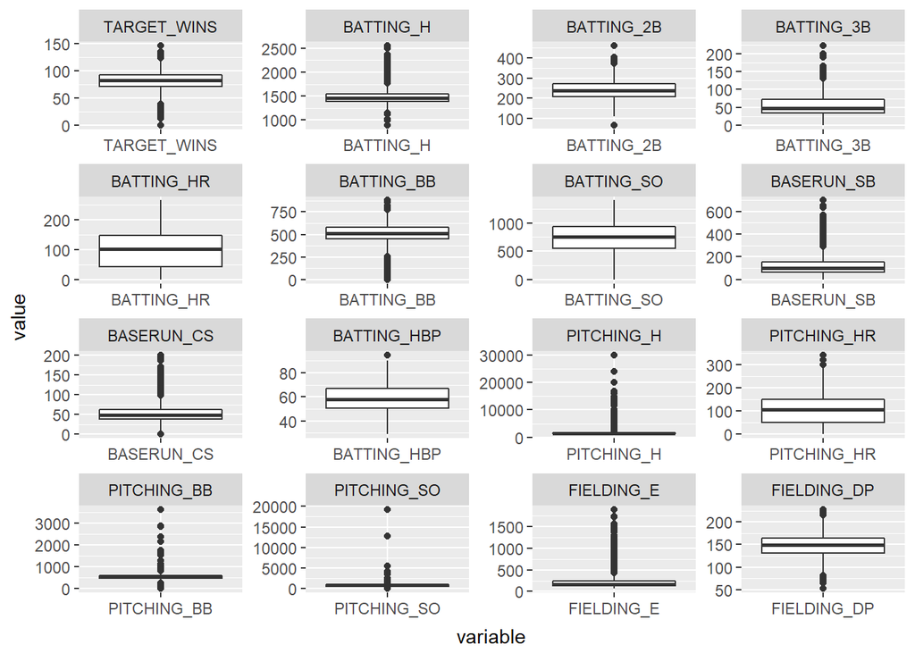

#### Variable Density Graphs

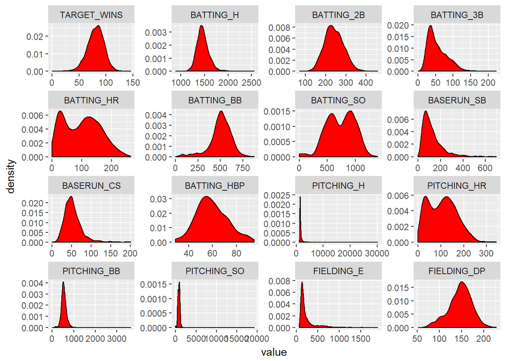

#### Scatterplot with Regression Line

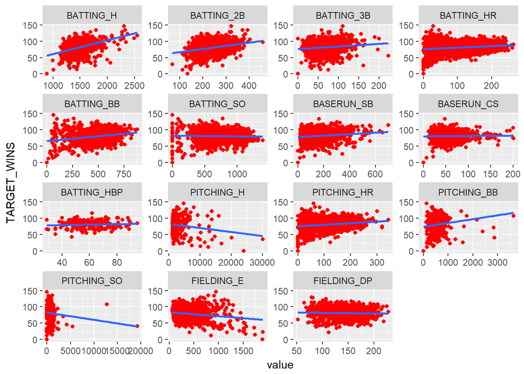

#### Correlation Matrix

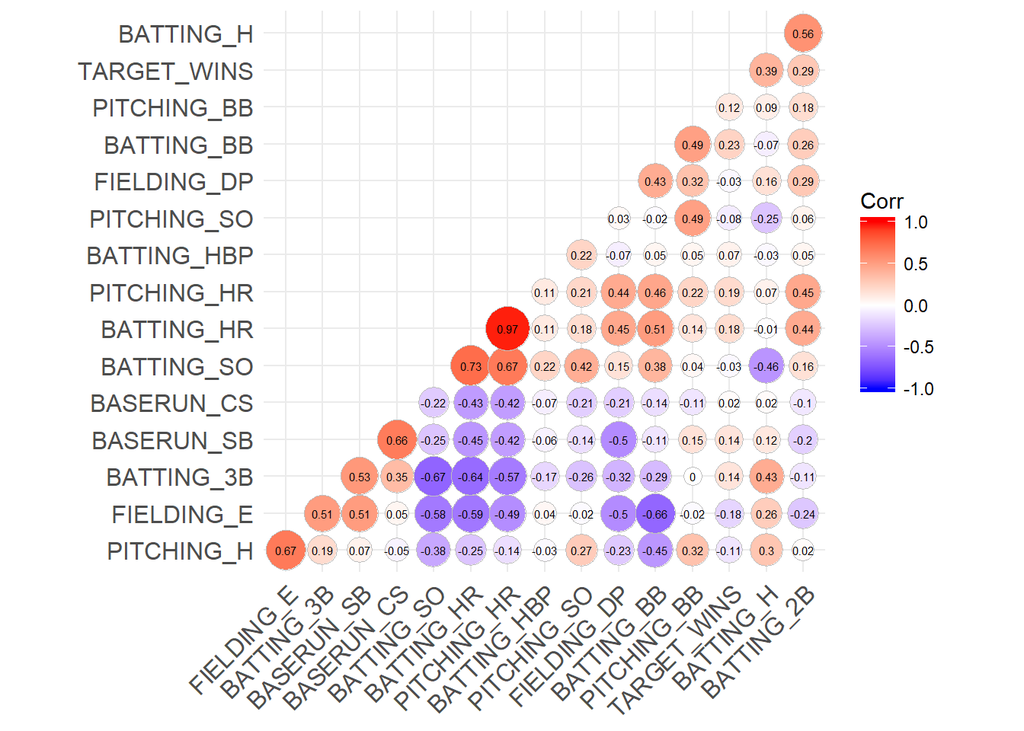

## 2. DATA PREPARATION (25 Points)

Describe how you have transformed the data by changing the original variables or creating new variables. If you did transform the data or create new variables, discuss why you did this. Here are some possible transformations. a. Fix missing values (maybe with a Mean or Median value) b. Create flags to suggest if a variable was missing c. Transform data by putting it into buckets d. Mathematical transforms such as log or square root (or use Box-Cox) e. Combine variables (such as ratios or adding or multiplying) to create new variables

#### Fix missing values

The chart below indicates that six out of sixteen variables have instances of null values. The median values for for ‘BASERUN_CS’, ‘FIELDING_DP’,‘BASERUN_SB’,‘BATTING_SO’,‘PITCHING_SO’ will serve as the replacement values. Since ‘HBP’BATTING_HBP’ has the majority of its data missing, the nulls will be replaced by zeros. Below is a dataframe of the number of null values prior to transformation

| Variable.Name | NA.COUNT | Unique.Values | Median |
| --- | --- | --- | --- |
| BATTING_HBP | 2085 | 56 | 58 |
| BASERUN_CS | 772 | 129 | 49 |
| FIELDING_DP | 286 | 145 | 149 |
| BASERUN_SB | 131 | 349 | 101 |
| BATTING_SO | 102 | 823 | 750 |
| PITCHING_SO | 102 | 824 | 813 |
| BATTING_2B | 0 | 240 | 238 |
| BATTING_3B | 0 | 144 | 47 |
| BATTING_BB | 0 | 533 | 512 |
| BATTING_H | 0 | 569 | 1454 |
| BATTING_HR | 0 | 243 | 102 |
| FIELDING_E | 0 | 549 | 159 |
| PITCHING_BB | 0 | 535 | 536 |
| PITCHING_H | 0 | 843 | 1518 |
| PITCHING_HR | 0 | 256 | 107 |
| TARGET_WINS | 0 | 108 | 82 |

### Feature Creation

*Combine variables (such as ratios or adding or multiplying) to create new variables*

The groups are derived from the initial variable description table. Variables that have a theoretical “Positive Impact on Wins” are particulary interesting and worth exploring. The first variable,offense,is the combination of the batting and stolen bases variables. The second variable, defense, are the fielding and pitching variables that help maintain leads/prevent losing.

- **Offense**: BATTING_H + BATTING_H + BATTING_2B + BATTING_3B+ BATTING_HR+ BATTING_BB+ BATTING_HBP +BASERUN_SB
- **Defense**: FIELDING_DP+ PITCHING_SO

#### Feature Creation Histograms

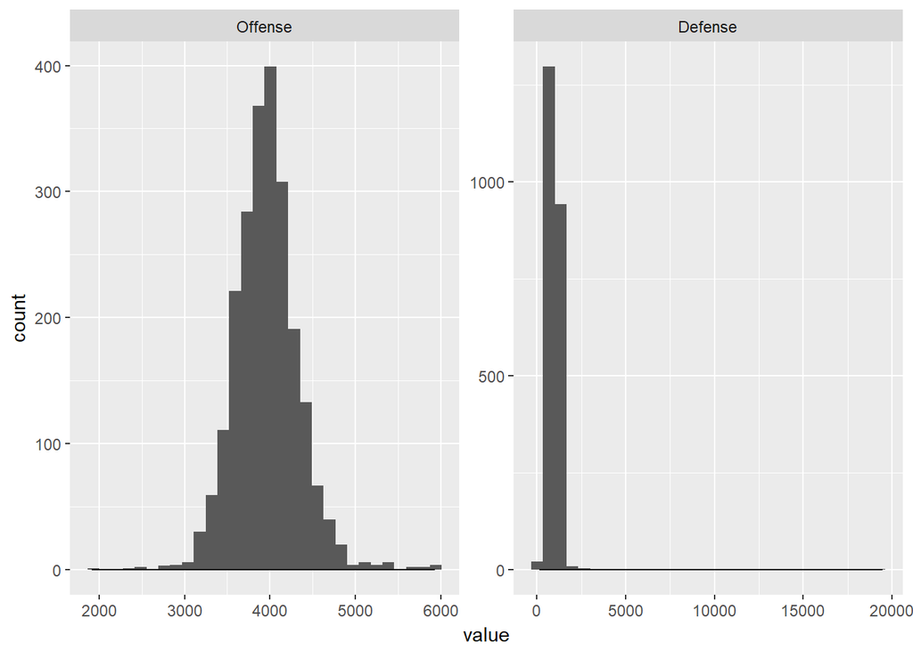

#### Feature Creation Box Plots

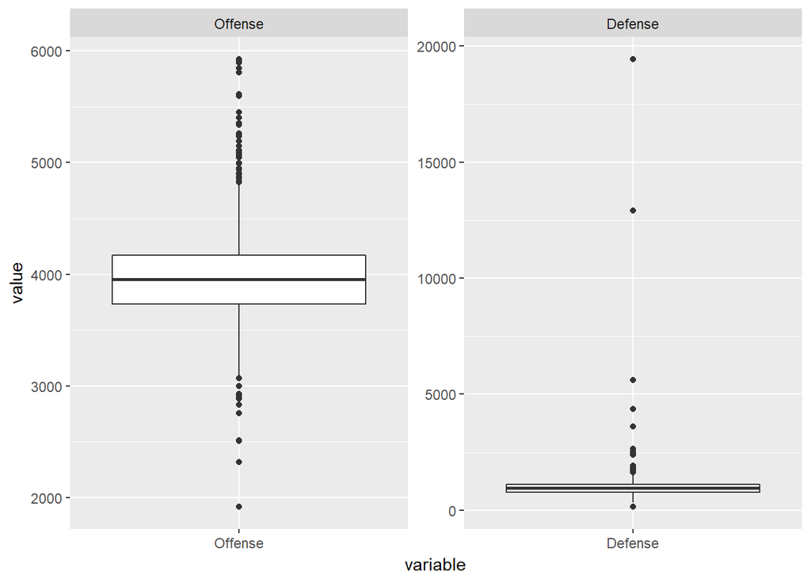

#### Correlation Matrix – Restructured Train Data (Removal of Nulls)

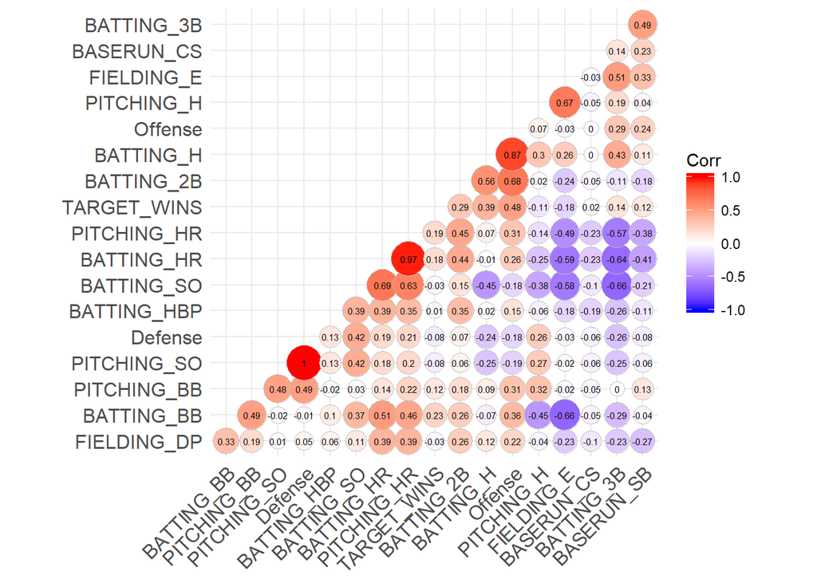

### 3. BUILD MODELS (25 Points)

Using the training data set, build at least three different multiple linear regression models, using different variables (or the same variables with different transformations). Since we have not yet covered automated variable selection methods, you should select the variables manually (unless you previously learned Forward or Stepwise selection, etc.). Since you manually selected a variable for inclusion into the model or exclusion into the model, indicate why this was done. Discuss the coefficients in the models, do they make sense? For example, if a team hits a lot of Home Runs, it would be reasonably expected that such a team would win more games. However, if the coefficient is negative (suggesting that the team would lose more games), then that needs to be discussed. Are you keeping the model even though it is counter intuitive? Why? The boss needs to know

#### Model 1: All variables - (raw data)

Model1 is the fitted result of the raw train.data, no transformations. The lm method removes all the NAs. The fitted Model1 will serve as the baseline for all subsequent models. ##### Model1 Summary

```
##
## Call:
## lm(formula = TARGET_WINS ~ ., data = train.data)
##
## Residuals:
##      Min       1Q   Median       3Q      Max
## -19.8708  -5.6564  -0.0599   5.2545  22.9274
##
## Coefficients:
##             Estimate Std. Error t value Pr(>|t|)
## (Intercept) 60.28826   19.67842   3.064  0.00253 **
## BATTING_H    1.91348    2.76139   0.693  0.48927
## BATTING_2B   0.02639    0.03029   0.871  0.38484
## BATTING_3B  -0.10118    0.07751  -1.305  0.19348
## BATTING_HR  -4.84371   10.50851  -0.461  0.64542
## BATTING_BB  -4.45969    3.63624  -1.226  0.22167
## BATTING_SO   0.34196    2.59876   0.132  0.89546
## BASERUN_SB   0.03304    0.02867   1.152  0.25071
## BASERUN_CS  -0.01104    0.07143  -0.155  0.87730
## BATTING_HBP  0.08247    0.04960   1.663  0.09815 .
## PITCHING_H  -1.89096    2.76095  -0.685  0.49432
## PITCHING_HR  4.93043   10.50664   0.469  0.63946
## PITCHING_BB  4.51089    3.63372   1.241  0.21612
## PITCHING_SO -0.37364    2.59705  -0.144  0.88577
## FIELDING_E  -0.17204    0.04140  -4.155 5.08e-05 ***
## FIELDING_DP -0.10819    0.03654  -2.961  0.00349 **
## ---
## Signif. codes:  0 '***' 0.001 '**' 0.01 '*' 0.05 '.' 0.1 ' ' 1
##
## Residual standard error: 8.467 on 175 degrees of freedom
##   (2085 observations deleted due to missingness)
## Multiple R-squared:  0.5501, Adjusted R-squared:  0.5116
## F-statistic: 14.27 on 15 and 175 DF,  p-value: < 2.2e-16
```

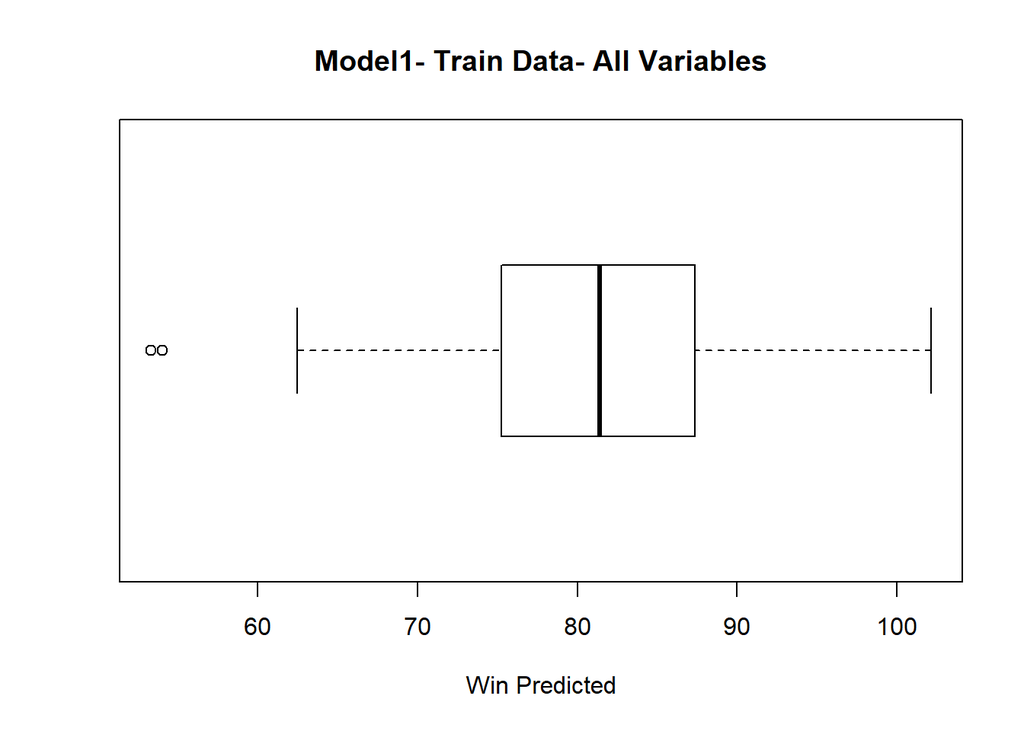

#### Model 2: All variables - (reformatted data)

```
##
## Call:
## lm(formula = TARGET_WINS ~ ., data = restructured.train.data)
##
## Residuals:
##     Min      1Q  Median      3Q     Max
## -50.091  -8.677   0.096   8.443  57.137
##
## Coefficients: (1 not defined because of singularities)
##               Estimate Std. Error t value Pr(>|t|)
## (Intercept) 22.5806880  5.3936111   4.187 2.94e-05 ***
## BATTING_H    0.0483619  0.0036920  13.099  < 2e-16 ***
## BATTING_2B  -0.0126588  0.0095151  -1.330  0.18352
## BATTING_3B   0.0654753  0.0167760   3.903 9.78e-05 ***
## BATTING_HR   0.0673154  0.0278160   2.420  0.01560 *
## BATTING_BB   0.0085351  0.0058575   1.457  0.14522
## BATTING_SO  -0.0068600  0.0025877  -2.651  0.00808 **
## BASERUN_SB   0.0263599  0.0043588   6.048 1.72e-09 ***
## BASERUN_CS  -0.0183965  0.0159197  -1.156  0.24798
## BATTING_HBP -0.0623727  0.0194200  -3.212  0.00134 **
## PITCHING_H  -0.0008177  0.0003668  -2.229  0.02589 *
## PITCHING_HR  0.0013612  0.0246113   0.055  0.95590
## PITCHING_BB  0.0014423  0.0041549   0.347  0.72852
## PITCHING_SO  1.1183884  2.5961286   0.431  0.66666
## FIELDING_E  -0.0191931  0.0024588  -7.806 8.96e-15 ***
## FIELDING_DP  0.9919422  2.5953867   0.382  0.70235
## Offense             NA         NA      NA       NA
## Defense     -1.1158381  2.5961285  -0.430  0.66738
## ---
## Signif. codes:  0 '***' 0.001 '**' 0.01 '*' 0.05 '.' 0.1 ' ' 1
##
## Residual standard error: 13.05 on 2259 degrees of freedom
## Multiple R-squared:  0.3185, Adjusted R-squared:  0.3137
## F-statistic:    66 on 16 and 2259 DF,  p-value: < 2.2e-16
```

##### Histogram of the Model2 Residuals

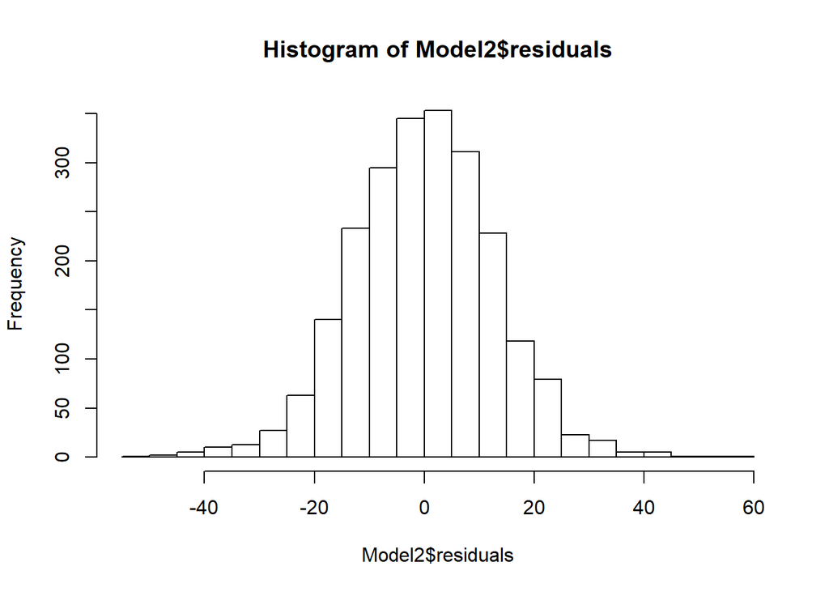

##### Plotted Residuals

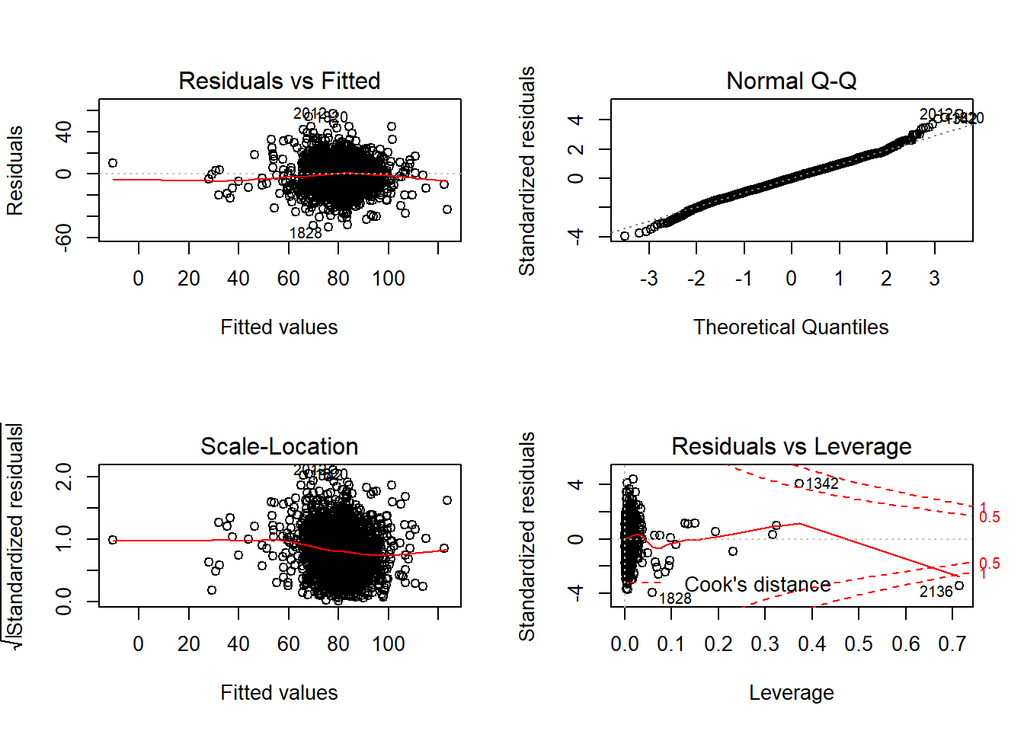

##### Predicted Wins- Model2

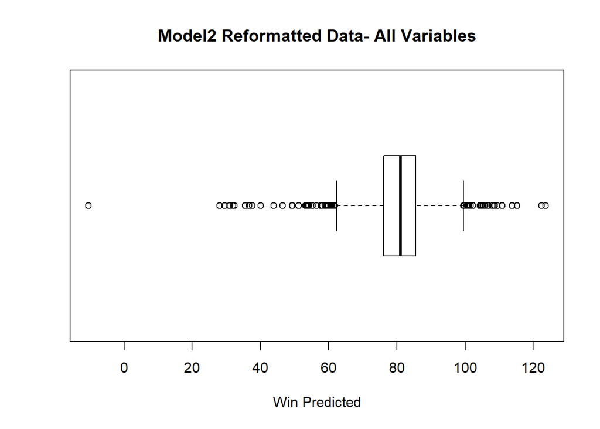

#### Model 3: Backward Elimination (Automated)

- Since the restructured model has seventeen explanatory variables, it is not feasible to fit all possible models. Below the backward elimination search algorithm is employed to find the best model. The r function step() was used to determine which variables should be removed from the model utilizing the AIC, Akaike’s Information Criteria. The smaller the AIC, the better the fit. The partial F-test is used to test if there is a significant change in the residual sum of squares from Model2 (all variables) to Backward.Model (backward elimination model). Based on the partial F-tested (summarized using the anova function) there is no evidence to believe that the nested model (Backward.Model) is significantly better than the full model (Model2). Fail to reject the null hypothesis.

```
test <- step(Model2, direction = "backward")
```

##### Backward.Model Summary

```
##
## Call:
## lm(formula = TARGET_WINS ~ BATTING_H + BATTING_3B + BATTING_HR +
##     BATTING_BB + BATTING_SO + BASERUN_SB + BATTING_HBP + PITCHING_H +
##     PITCHING_SO + FIELDING_E + Defense, data = restructured.train.data)
##
## Residuals:
##     Min      1Q  Median      3Q     Max
## -50.026  -8.621   0.159   8.289  56.168
##
## Coefficients:
##               Estimate Std. Error t value Pr(>|t|)
## (Intercept) 23.3785334  5.0067700   4.669 3.20e-06 ***
## BATTING_H    0.0449880  0.0028078  16.022  < 2e-16 ***
## BATTING_3B   0.0686868  0.0165369   4.154 3.40e-05 ***
## BATTING_HR   0.0709784  0.0096581   7.349 2.77e-13 ***
## BATTING_BB   0.0100918  0.0033629   3.001 0.002721 **
## BATTING_SO  -0.0076681  0.0024615  -3.115 0.001861 **
## BASERUN_SB   0.0262441  0.0041703   6.293 3.73e-10 ***
## BATTING_HBP -0.0666003  0.0183193  -3.636 0.000284 ***
## PITCHING_H  -0.0007715  0.0003204  -2.408 0.016106 *
## PITCHING_SO  0.1270159  0.0129642   9.797  < 2e-16 ***
## FIELDING_E  -0.0179991  0.0023669  -7.605 4.16e-14 ***
## Defense     -0.1243508  0.0129183  -9.626  < 2e-16 ***
## ---
## Signif. codes:  0 '***' 0.001 '**' 0.01 '*' 0.05 '.' 0.1 ' ' 1
##
## Residual standard error: 13.05 on 2264 degrees of freedom
## Multiple R-squared:  0.3174, Adjusted R-squared:  0.3141
## F-statistic: 95.71 on 11 and 2264 DF,  p-value: < 2.2e-16
```

##### Partial F-test Backward.Model vs Model2

```
## Analysis of Variance Table
##
## Model 1: TARGET_WINS ~ BATTING_H + BATTING_3B + BATTING_HR + BATTING_BB +
##     BATTING_SO + BASERUN_SB + BATTING_HBP + PITCHING_H + PITCHING_SO +
##     FIELDING_E + Defense
## Model 2: TARGET_WINS ~ BATTING_H + BATTING_2B + BATTING_3B + BATTING_HR +
##     BATTING_BB + BATTING_SO + BASERUN_SB + BASERUN_CS + BATTING_HBP +
##     PITCHING_H + PITCHING_HR + PITCHING_BB + PITCHING_SO + FIELDING_E +
##     FIELDING_DP + Offense + Defense
##   Res.Df    RSS Df Sum of Sq      F Pr(>F)
## 1   2264 385313
## 2   2259 384680  5    633.32 0.7438 0.5906
```

##### Histogram of Residuals

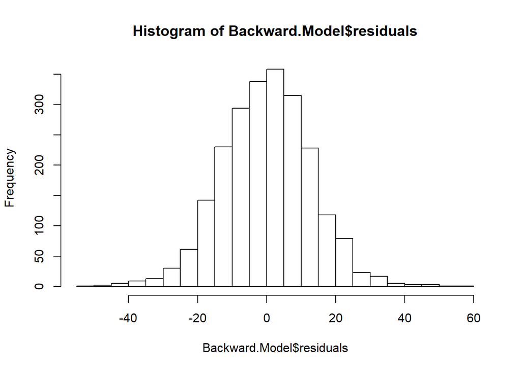

##### Plotted Residuals

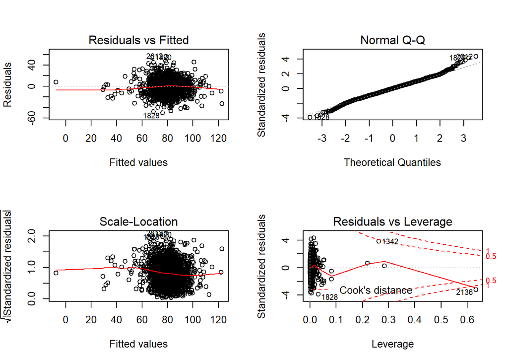

##### Predicted Wins- Backward.Model

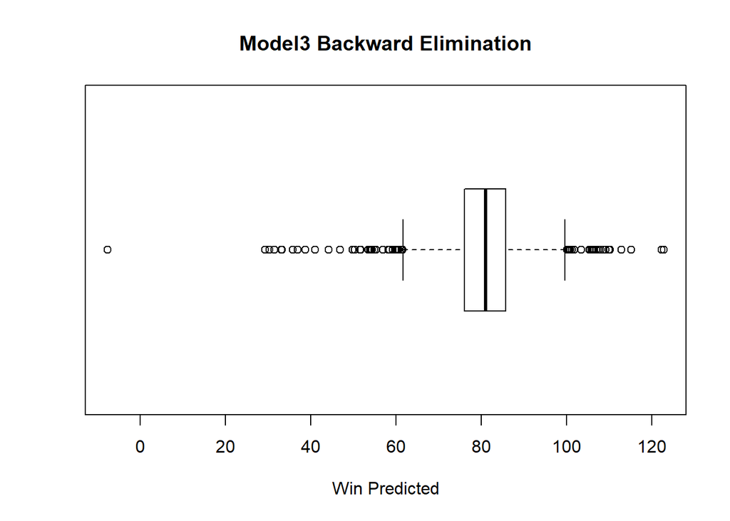

#### Model 4: Manual Selection of Variables

##### Model4 Summary

```
##
## Call:
## lm(formula = TARGET_WINS ~ BATTING_H + BATTING_3B + BATTING_HR +
##     BATTING_BB + BATTING_SO + BASERUN_SB + BATTING_HBP + PITCHING_H +
##     PITCHING_SO + FIELDING_E + Defense, data = restructured.train.data)
##
## Residuals:
##     Min      1Q  Median      3Q     Max
## -50.026  -8.621   0.159   8.289  56.168
##
## Coefficients:
##               Estimate Std. Error t value Pr(>|t|)
## (Intercept) 23.3785334  5.0067700   4.669 3.20e-06 ***
## BATTING_H    0.0449880  0.0028078  16.022  < 2e-16 ***
## BATTING_3B   0.0686868  0.0165369   4.154 3.40e-05 ***
## BATTING_HR   0.0709784  0.0096581   7.349 2.77e-13 ***
## BATTING_BB   0.0100918  0.0033629   3.001 0.002721 **
## BATTING_SO  -0.0076681  0.0024615  -3.115 0.001861 **
## BASERUN_SB   0.0262441  0.0041703   6.293 3.73e-10 ***
## BATTING_HBP -0.0666003  0.0183193  -3.636 0.000284 ***
## PITCHING_H  -0.0007715  0.0003204  -2.408 0.016106 *
## PITCHING_SO  0.1270159  0.0129642   9.797  < 2e-16 ***
## FIELDING_E  -0.0179991  0.0023669  -7.605 4.16e-14 ***
## Defense     -0.1243508  0.0129183  -9.626  < 2e-16 ***
## ---
## Signif. codes:  0 '***' 0.001 '**' 0.01 '*' 0.05 '.' 0.1 ' ' 1
##
## Residual standard error: 13.05 on 2264 degrees of freedom
## Multiple R-squared:  0.3174, Adjusted R-squared:  0.3141
## F-statistic: 95.71 on 11 and 2264 DF,  p-value: < 2.2e-16
```

##### Multi-collinearity Test

```
##   BATTING_H  BATTING_3B  BATTING_HR  BATTING_BB  BATTING_SO  BASERUN_SB
##    2.203274    2.853386    4.571000    2.274894    4.778815    1.695716
## BATTING_HBP  PITCHING_H PITCHING_SO  FIELDING_E     Defense
##    1.278557    2.715353  656.440582    3.885045  653.713029
```

##### Removal of Defense & PITCHING_SO

```
##
## Call:
## lm(formula = TARGET_WINS ~ BATTING_H + BATTING_3B + BATTING_HR +
##     BATTING_BB + BATTING_SO + BASERUN_SB + BATTING_HBP + PITCHING_H +
##     FIELDING_E, data = restructured.train.data)
##
## Residuals:
##     Min      1Q  Median      3Q     Max
## -53.673  -9.154   0.046   8.881  62.489
##
## Coefficients:
##               Estimate Std. Error t value Pr(>|t|)
## (Intercept)  9.4867980  4.9048519   1.934 0.053217 .
## BATTING_H    0.0425583  0.0028538  14.913  < 2e-16 ***
## BATTING_3B   0.0803083  0.0168537   4.765 2.01e-06 ***
## BATTING_HR   0.0484016  0.0096129   5.035 5.15e-07 ***
## BATTING_BB   0.0034805  0.0033627   1.035 0.300765
## BATTING_SO  -0.0007553  0.0022557  -0.335 0.737781
## BASERUN_SB   0.0319973  0.0042196   7.583 4.89e-14 ***
## BATTING_HBP -0.0624842  0.0187006  -3.341 0.000847 ***
## PITCHING_H  -0.0002361  0.0002894  -0.816 0.414681
## FIELDING_E  -0.0198418  0.0024096  -8.235 3.01e-16 ***
## ---
## Signif. codes:  0 '***' 0.001 '**' 0.01 '*' 0.05 '.' 0.1 ' ' 1
##
## Residual standard error: 13.34 on 2266 degrees of freedom
## Multiple R-squared:  0.2856, Adjusted R-squared:  0.2828
## F-statistic: 100.7 on 9 and 2266 DF,  p-value: < 2.2e-16
```

##### Partial F-test Model4 vs Model2

```
## Analysis of Variance Table
##
## Model 1: TARGET_WINS ~ BATTING_H + BATTING_3B + BATTING_HR + BATTING_BB +
##     BATTING_SO + BASERUN_SB + BATTING_HBP + PITCHING_H + FIELDING_E
## Model 2: TARGET_WINS ~ BATTING_H + BATTING_2B + BATTING_3B + BATTING_HR +
##     BATTING_BB + BATTING_SO + BASERUN_SB + BASERUN_CS + BATTING_HBP +
##     PITCHING_H + PITCHING_HR + PITCHING_BB + PITCHING_SO + FIELDING_E +
##     FIELDING_DP + Offense + Defense
##   Res.Df    RSS Df Sum of Sq      F    Pr(>F)
## 1   2266 403276
## 2   2259 384680  7     18596 15.601 < 2.2e-16 ***
## ---
## Signif. codes:  0 '***' 0.001 '**' 0.01 '*' 0.05 '.' 0.1 ' ' 1
```

##### Histogram of Residuals

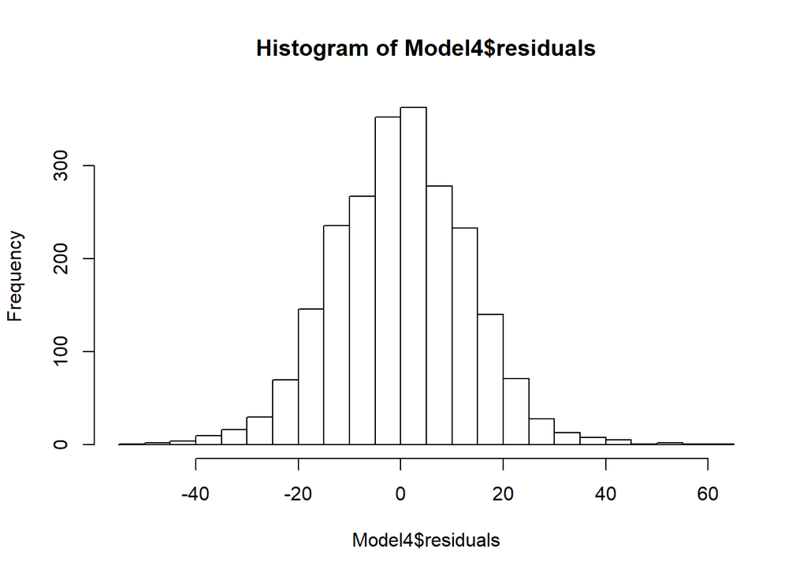

##### Plotted Residuals

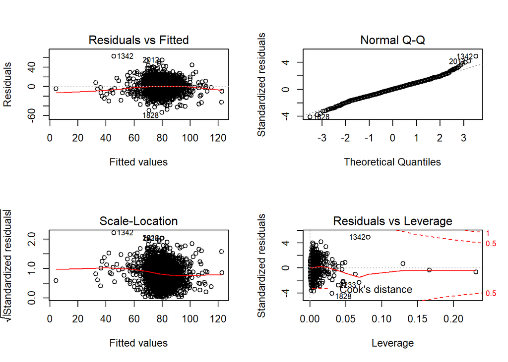

##### Predicted Wins- Model4

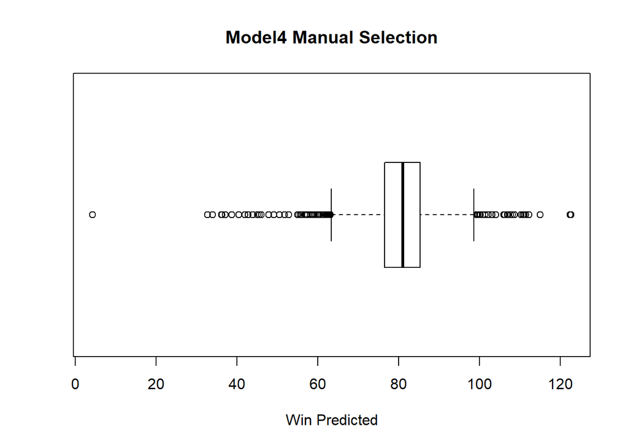

#### Model 5: Remove Outliers

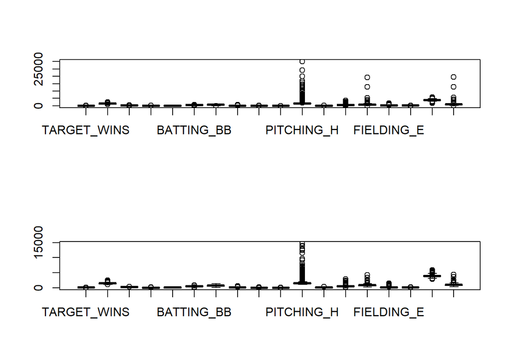

  ##### Model5 Summary - All Variables

```
##
## Call:
## lm(formula = TARGET_WINS ~ ., data = outlier.removed.df)
##
## Residuals:
##     Min      1Q  Median      3Q     Max
## -47.452  -8.365   0.031   8.213  62.130
##
## Coefficients: (1 not defined because of singularities)
##               Estimate Std. Error t value Pr(>|t|)
## (Intercept) 26.5243667  5.7856538   4.585 4.80e-06 ***
## BATTING_H    0.0422281  0.0043718   9.659  < 2e-16 ***
## BATTING_2B  -0.0158163  0.0097703  -1.619  0.10563
## BATTING_3B   0.0960985  0.0177622   5.410 6.97e-08 ***
## BATTING_HR   0.0802480  0.0349540   2.296  0.02178 *
## BATTING_BB   0.0313698  0.0073261   4.282 1.93e-05 ***
## BATTING_SO  -0.0194607  0.0045424  -4.284 1.91e-05 ***
## BASERUN_SB   0.0314907  0.0045735   6.885 7.47e-12 ***
## BASERUN_CS  -0.0237154  0.0160200  -1.480  0.13892
## BATTING_HBP -0.0569392  0.0193760  -2.939  0.00333 **
## PITCHING_H   0.0009338  0.0007161   1.304  0.19234
## PITCHING_HR -0.0077793  0.0316538  -0.246  0.80589
## PITCHING_BB -0.0157948  0.0056337  -2.804  0.00510 **
## PITCHING_SO  1.1924057  2.5542768   0.467  0.64067
## FIELDING_E  -0.0268707  0.0030322  -8.862  < 2e-16 ***
## FIELDING_DP  1.0538104  2.5535650   0.413  0.67988
## Offense             NA         NA      NA       NA
## Defense     -1.1780954  2.5543006  -0.461  0.64469
## ---
## Signif. codes:  0 '***' 0.001 '**' 0.01 '*' 0.05 '.' 0.1 ' ' 1
##
## Residual standard error: 12.84 on 2224 degrees of freedom
## Multiple R-squared:  0.2884, Adjusted R-squared:  0.2833
## F-statistic: 56.33 on 16 and 2224 DF,  p-value: < 2.2e-16
```

##### Model5 Summary - Variables

```
##
## Call:
## lm(formula = TARGET_WINS ~ BATTING_H + BATTING_3B + BATTING_HR +
##     BATTING_BB + BASERUN_SB + BATTING_HBP + FIELDING_E + FIELDING_DP,
##     data = outlier.removed.df)
##
## Residuals:
##     Min      1Q  Median      3Q     Max
## -51.569  -8.422   0.060   8.292  58.579
##
## Coefficients:
##              Estimate Std. Error t value Pr(>|t|)
## (Intercept) 21.304931   3.478550   6.125 1.07e-09 ***
## BATTING_H    0.041485   0.002492  16.649  < 2e-16 ***
## BATTING_3B   0.101426   0.016748   6.056 1.63e-09 ***
## BATTING_HR   0.063502   0.007855   8.084 1.02e-15 ***
## BATTING_BB   0.013661   0.003333   4.099 4.30e-05 ***
## BASERUN_SB   0.024085   0.004024   5.986 2.50e-09 ***
## BATTING_HBP -0.074814   0.017740  -4.217 2.57e-05 ***
## FIELDING_E  -0.019825   0.002178  -9.104  < 2e-16 ***
## FIELDING_DP -0.123500   0.012755  -9.682  < 2e-16 ***
## ---
## Signif. codes:  0 '***' 0.001 '**' 0.01 '*' 0.05 '.' 0.1 ' ' 1
##
## Residual standard error: 12.89 on 2232 degrees of freedom
## Multiple R-squared:  0.2801, Adjusted R-squared:  0.2775
## F-statistic: 108.6 on 8 and 2232 DF,  p-value: < 2.2e-16
```

##### Multi-collinearity Test

```
##   BATTING_H  BATTING_3B  BATTING_HR  BATTING_BB  BASERUN_SB BATTING_HBP
##    1.545331    2.851436    2.983312    1.943795    1.573260    1.211432
##  FIELDING_E FIELDING_DP
##    2.437211    1.329582
```

##### Histogram of Residuals

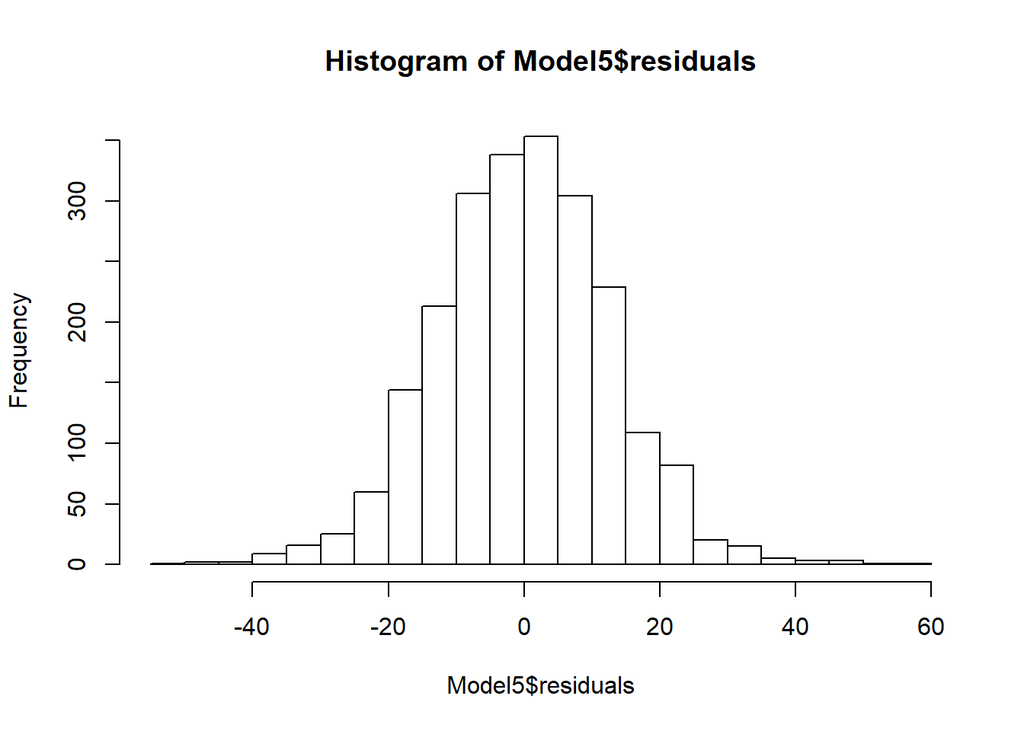

##### Plotted Residuals

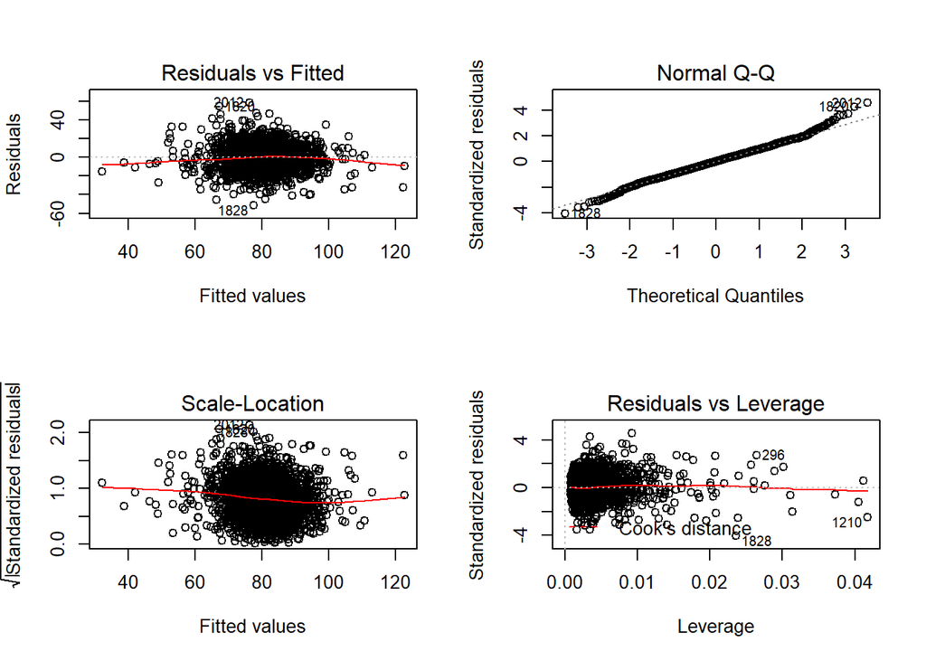

##### Predicted Wins- Model5

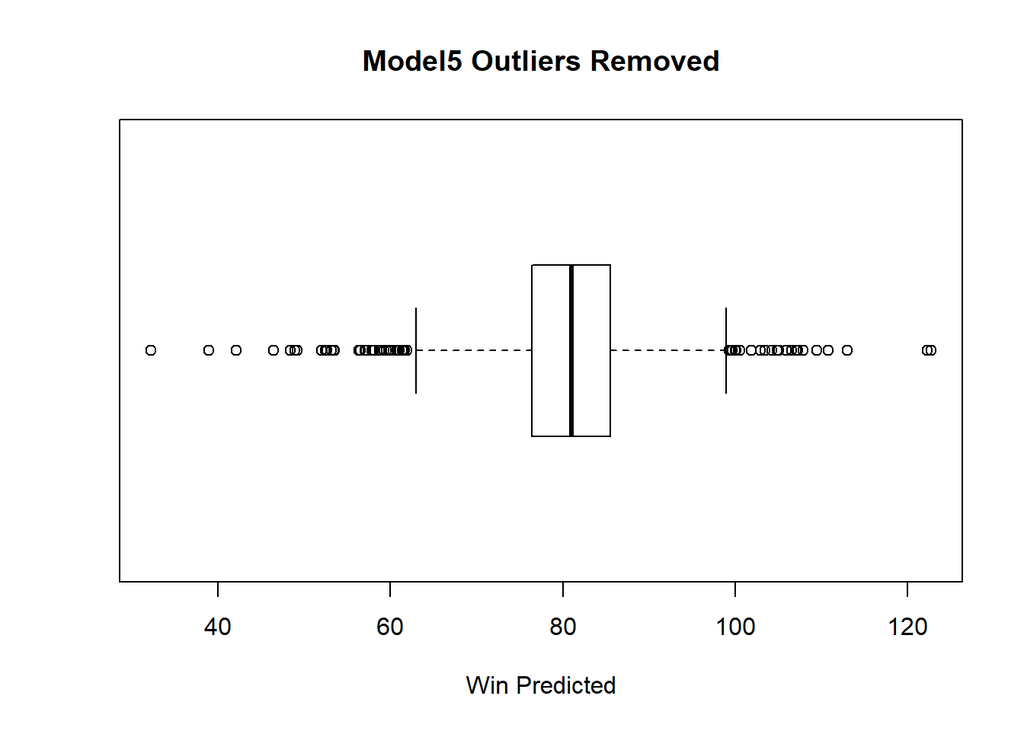

#### Model 6: Log Transformations

- For this model the skewness of each variable is evaluated. If the absolute value of the explanitory variable’s skewness is above one, a log transformation of the variable replaces the variable. the linear model is then fitted with the transformed variables. The log transformed variables are “BATTING_H”, “BATTING_3B”, “BATTING_BB”, “BASERUN_SB”, “BASERUN_CS”, “PITCHING_H”, “PITCHING_BB”, “PITCHING_SO”, “FIELDING_E” & “Defense”

After the fitted model is assessed, the same variables that are removed in Model4 are removed from Model6 for comparrison purposes.

##### All variables printed below will undergo the log transformation

```
## [1] "BATTING_H"
## [1] "BATTING_3B"
## [1] "BATTING_BB"
## [1] "BASERUN_SB"
## [1] "BASERUN_CS"
## [1] "PITCHING_H"
## [1] "PITCHING_BB"
## [1] "PITCHING_SO"
## [1] "FIELDING_E"
## [1] "Defense"
```

```
##
## Call:
## lm(formula = TARGET_WINS ~ ., data = log.df)
##
## Residuals:
##     Min      1Q  Median      3Q     Max
## -56.548  -8.207  -0.105   7.986  58.565
##
## Coefficients:
##               Estimate Std. Error t value Pr(>|t|)
## (Intercept) 137.826377 116.427452   1.184  0.23662
## BATTING_H    -6.570598  13.281250  -0.495  0.62084
## BATTING_2B   -0.058675   0.010542  -5.566 2.92e-08 ***
## BATTING_3B    2.976522   0.969506   3.070  0.00217 **
## BATTING_HR    0.036400   0.027934   1.303  0.19269
## BATTING_BB  -18.875201   7.130556  -2.647  0.00818 **
## BATTING_SO   -0.046609   0.004926  -9.462  < 2e-16 ***
## BASERUN_SB    0.977520   0.866680   1.128  0.25949
## BASERUN_CS   -2.442333   1.011167  -2.415  0.01580 *
## BATTING_HBP  -0.097818   0.019672  -4.973 7.11e-07 ***
## PITCHING_H  -28.129615   6.492804  -4.332 1.54e-05 ***
## PITCHING_HR  -0.024274   0.023861  -1.017  0.30911
## PITCHING_BB   6.703631   5.382779   1.245  0.21312
## PITCHING_SO -12.307631   1.346309  -9.142  < 2e-16 ***
## FIELDING_E  -12.740618   1.071879 -11.886  < 2e-16 ***
## FIELDING_DP  -0.185465   0.014159 -13.099  < 2e-16 ***
## Offense       0.037960   0.005106   7.435 1.48e-13 ***
## Defense      49.835249   4.808094  10.365  < 2e-16 ***
## ---
## Signif. codes:  0 '***' 0.001 '**' 0.01 '*' 0.05 '.' 0.1 ' ' 1
##
## Residual standard error: 12.73 on 2258 degrees of freedom
## Multiple R-squared:  0.3515, Adjusted R-squared:  0.3467
## F-statistic: 72.01 on 17 and 2258 DF,  p-value: < 2.2e-16
```

##### Model6 Summary

[output not shown]

##### Multi-collinearity Test

[output not shown]

##### Histogram of Residuals

[figure not shown]

##### Plotted Residuals

[figure not shown]

##### Predicted Wins- Model6

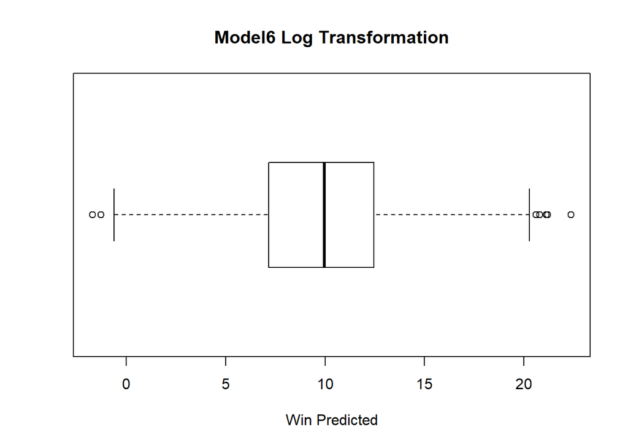

### 4. SELECT MODELS (25 Points)

Decide on the criteria for selecting the best multiple linear regression model. Will you select a model with slightly worse performance if it makes more sense or is more parsimonious? Discuss why you selected your model. For the multiple linear regression model, will you use a metric such as Adjusted R2, RMSE, etc.? Be sure to explain how you can make inferences from the model, discuss multi-collinearity issues (if any), and discuss other relevant model output. Using the training data set, evaluate the multiple linear regression model based on (a) mean squared error, (b) R2, (c) F-statistic, and (d) residual plots. Make predictions using the evaluation data set.

##### Plotted Target Wins - Density Plot

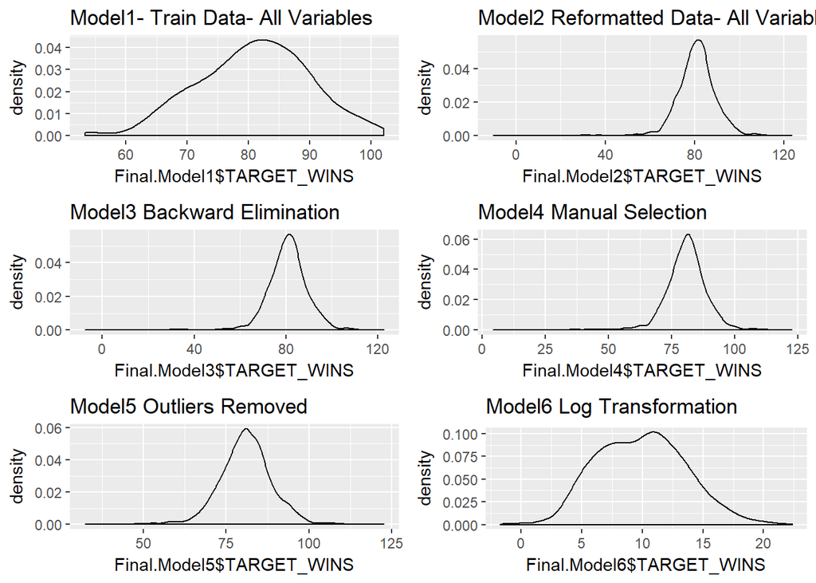

##### Plotted Target Wins - Boxplot

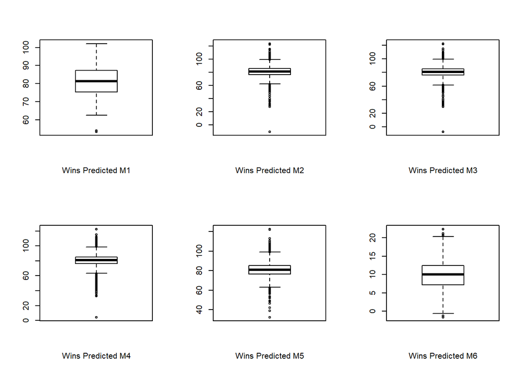

#### Calculate the R Squared For Each Model:

```
## [1] 0.5501165 0.3185429 0.3174210 0.2855998 0.2800997 0.2800997
```

#### Calculate the Mean Squared Error (MSE) for Each Model:

```
## [1]  65.68529 169.01586 169.29412 177.18645 165.45545 165.45545
```

#### Calculate the F Statistic for Each Model:

```
## [1]  14.26597  65.99723  95.71202 100.65463 108.55368 108.55368
```

#### Final Summary All Models

| model.name | r.sq | mse | f.stat |
| --- | --- | --- | --- |
| Model1 | 0.55 | 65.69 | 14.27 |
| Model2 | 0.32 | 169.02 | 66 |
| Model3 | 0.32 | 169.29 | 95.71 |
| Model4 | 0.29 | 177.19 | 100.65 |
| Model5 | 0.28 | 165.46 | 108.55 |
| Model6 | 0.28 | 165.46 | 108.55 |

#### Model Selected

##### Model 5 Plotted Predicted Values (Evaluation Data)

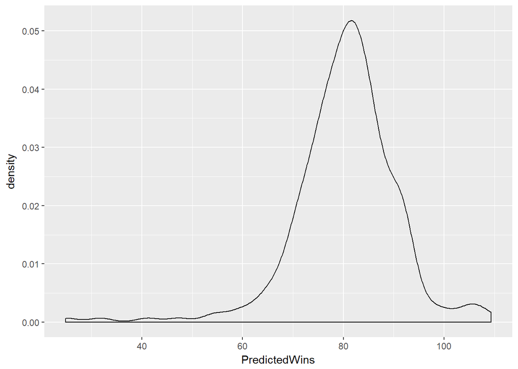

| PredictedWins |
| --- |
| 65.63607 |
| 65.90673 |
| 74.40960 |
| 83.77266 |
| 63.71139 |
| 67.52580 |